# Project: Wrangle and Analyze Data: @WeRateDogs

```python
#read image tsv file csv dataframe
image = pd.read_csv('image-predictions.tsv', sep='\t')
image
```

|  | tweet_id | jpg_url | img_num | p1 | p1_conf | p1_dog | p2 | p2_conf | p2_dog | p3 | p3_conf | p3_dog |
| --- | --- | --- | --- | --- | --- | --- | --- | --- | --- | --- | --- | --- |
| 0 | 666020888022790149 | https://pbs.twimg.com/media/CT4udn0WwAA0aMy.jpg | 1 | Welsh_springer_spaniel | 0.465074 | True | collie | 0.156665 | True | Shetland_sheepdog | 0.061428 | True |
| 1 | 666029285002620928 | https://pbs.twimg.com/media/CT42GRgUYAA5iDo.jpg | 1 | redbone | 0.506826 | True | miniature_pinscher | 0.074192 | True | Rhodesian_ridgeback | 0.072010 | True |
| 2 | 666033412701032449 | https://pbs.twimg.com/media/CT4521TWwAEvMyu.jpg | 1 | German_shepherd | 0.596461 | True | malinois | 0.138584 | True | bloodhound | 0.116197 | True |
| 3 | 666044226329800704 | https://pbs.twimg.com/media/CT5Dr8HUEAA-lEu.jpg | 1 | Rhodesian_ridgeback | 0.408143 | True | redbone | 0.360687 | True | miniature_pinscher | 0.222752 | True |
| 4 | 666049248165822465 | https://pbs.twimg.com/media/CT5IQmsXIAAKY4A.jpg | 1 | miniature_pinscher | 0.560311 | True | Rottweiler | 0.243682 | True | Doberman | 0.154629 | True |
| ... | ... | ... | ... | ... | ... | ... | ... | ... | ... | ... | ... | ... |
| 2070 | 891327558926688256 | https://pbs.twimg.com/media/DF6hr6BUMAAzZgT.jpg | 2 | basset | 0.555712 | True | English_springer | 0.225770 | True | German_short-haired_pointer | 0.175219 | True |
| 2071 | 891689557279858688 | https://pbs.twimg.com/media/DF_q7IAWsAEuuN8.jpg | 1 | paper_towel | 0.170278 | False | Labrador_retriever | 0.168086 | True | spatula | 0.040836 | False |
| 2072 | 891815181378084864 | https://pbs.twimg.com/media/DGBdLU1WsAANxJ9.jpg | 1 | Chihuahua | 0.716012 | True | malamute | 0.078253 | True | kelpie | 0.031379 | True |
| 2073 | 892177421306343426 | https://pbs.twimg.com/media/DGGmoV4XsAAUL6n.jpg | 1 | Chihuahua | 0.323581 | True | Pekinese | 0.090647 | True | papillon | 0.068957 | True |
| 2074 | 892420643555336193 | https://pbs.twimg.com/media/DGKD1-bXoAAIAUK.jpg | 1 | orange | 0.097049 | False | bagel | 0.085851 | False | banana | 0.076110 | False |

2075 rows × 12 columns

```python
image.to_csv('image.csv')
```

1. Use the Tweepy library to query additional data via the Twitter API (tweet_json.txt)

```python
#apply tweepy library and twitter api credentials
api_key = 'HA1Ndy7PWQxpT6TVuJSLnxYvu'
api_secret_key='jAMYaPPXgMUWwvWPolU9VgJwcUlUfL1oBDYClk0fsnJMBih4CB'
access_token = '635552224-c1X2UbXR3fjwZ71PvE8WsqNbN0qBhAuwFyt9N7SX'
access_secret_token='gDRRqSz5GbnyqCuhHKQu6euVU6BrJuCyt5pDxyhIAYgAe'

#client = tweepy.Client(api_key, api_secret_key)
auth = tweepy.OAuthHandler(api_key, api_secret_key)
auth.set_access_token(access_token, access_secret_token)
api = tweepy.API(auth, wait_on_rate_limit=True)
```

```python
#exclude retweets data as per the instructions
tweets = api.user_timeline(screen_name = 'dog_rates',
include_rts = False,
tweet_mode = 'extended')
```

```python
for info in tweets[:]:
    print('ID {}'.format(info.id))
    print('Date: {}'.format(info.created_at))
    print(info.full_text)
    print('\n')
```

```
ID 1578790492166230017
Date: 2022-10-08 16:52:40+00:00
@perfecthennig not necessary we have him under control


ID 1578789892707983362
Date: 2022-10-08 16:50:17+00:00
@410fredo good because that snake would love some head pats


ID 1578788859483136000
Date: 2022-10-08 16:46:11+00:00
We only rate dogs. This is a very fast snake. You're lucky he stopped when he did. Please only send dogs. Thank you... 13/10 #SeniorPupSaturday https://t.co/w0OmhvwMoM


ID 1578419229795172357
Date: 2022-10-07 16:17:24+00:00
@Dee_sguise his new arch nemesis


ID 1578419132508299266
Date: 2022-10-07 16:17:01+00:00
@RissRiss24 alert the media


ID 1578419060240523265
Date: 2022-10-07 16:16:44+00:00
@peakingsassy PUPPY GAZE


ID 1578417367872581632
Date: 2022-10-07 16:10:00+00:00
Accidents happen. Tobi asks that you please consider getting @Trupanion so you never have to send us a GoFundMe. Click the link below to get a quote. It’s best to be puppared ❤️ #partner

https://t.co/vUNBJ3ianu https://t.co/EuhcjELPOZ


ID 1578417361228812288
Date: 2022-10-07 16:09:59+00:00
This is Tobi. He was pretending to be a superhero when he leapt from his human's bed in an attempt to fly. Broke his leg upon landing and needed surgery so it can heal properly. We paid for the remainder of his care, and he's still a superhero to us. 13/10 https://t.co/OakmqJjE6l
```

[output cut: 37 more lines]

```


ID 1578150370441891842
Date: 2022-10-06 22:29:03+00:00
@AstroShanna don't forget dinner


ID 1578148884660080641
Date: 2022-10-06 22:23:09+00:00
@JediTigger this Mapo Tofu is friend not food


ID 1578147372525305858
Date: 2022-10-06 22:17:08+00:00
@lmartin0011 he wants now thank you
```

```python
#identify total number of tweets in dataframe
tweet_ids = archives.tweet_id.values
len(tweet_ids)
```

```
2356
```

```python
#get status of a tweet
status = api.get_status(1570432515994951680, tweet_mode = 'extended')
status
```

```
Status(_api=<tweepy.api.API object at 0x7fe200ca8c40>, _json={'created_at': 'Thu Sep 15 15:21:03 +0000 2022', 'id': 1570432515994951680, 'id_str': '1570432515994951680', 'full_text': '@JAPayne75 hi Daisy welcome home ❤️', 'truncated': False, 'display_text_range': [11, 35], 'entities': {'hashtags': […
```

```python
import time
import json

# Query Twitter's API for JSON data for the 2356 tweets ids
count = 0

# creating an error dictionary to record potential errors
error_dict = {}
start_time = time.time()

# Saving each tweet's returned JSON on a separate line and in a text file
with open('tweet_json.txt', 'w') as file:
   #give it some time for all tweets to generate
    for tweet_id in tweet_ids:
        count += 1
        print(str(count) + ": " + str(tweet_id))
        try:
            # Getting the status id of each tweet id
            tweet = api.get_status(tweet_id, tweet_mode='extended')
            print("Success")
            # Converting each tweet status to a JSON object/string and saving to a file
            json.dump(tweet._json, file)
            file.write('\n')
        # Catching errors that occured
        except tweepy.TweepyException:
            print("Fail")
            # Appending errors to error_dict
            error_dict[tweet_id] = 'fail'
            pass
end_time = time.time()
print(end_time - start_time)
```

[output not shown]

[output cut: 1746 more lines]

[output not shown]

```
Rate limit reached. Sleeping for: 761
```

[output not shown]

[output cut: 1743 more lines]

[output not shown]

```
Rate limit reached. Sleeping for: 720
```

[output not shown]

[output cut: 1059 more lines]

[output not shown]

```python
len(error_dict)
```

```
30
```

```python
#with an empty list write the tweets data from the json file into list
tweets=list()
with open ('tweet_json.txt', 'r') as f:
    for l in f.readlines():

            json_data = json.loads(l)
            tweet_id = json_data['id']
            rt_count = json_data['retweet_count']
            fav_count = json_data['favorite_count']
            tweets.append({
                "tweet_id" : tweet_id,
                "retweet_count" : int(rt_count),
                "fav_count": int(fav_count)})

tweets = pd.DataFrame(tweets, columns = ['tweet_id','retweet_count','fav_count'])
tweets
```

|  | tweet_id | retweet_count | fav_count |
| --- | --- | --- | --- |
| 0 | 892420643555336193 | 6951 | 33606 |
| 1 | 892177421306343426 | 5253 | 29150 |
| 2 | 891815181378084864 | 3460 | 21934 |
| 3 | 891689557279858688 | 7162 | 36663 |
| 4 | 891327558926688256 | 7699 | 35057 |
| ... | ... | ... | ... |
| 2321 | 666049248165822465 | 36 | 88 |
| 2322 | 666044226329800704 | 114 | 245 |
| 2323 | 666033412701032449 | 36 | 100 |
| 2324 | 666029285002620928 | 39 | 112 |
| 2325 | 666020888022790149 | 418 | 2276 |

2326 rows × 3 columns

## Assessing Data

This is where we check the gathered data for tidiness and quality.

- Low quality data means the data is dirty
- Untidy data has structural issues which make analysis difficult and results are inaccurate

### a. Assess archives dataset

##### columns descriptions

. tweet_id - unique numeric code assigned to each tweet

.in_reply_to_status_id - If the represented Tweet is a reply, this field will contain the integer representation of the original Tweet’s ID

.in_reply_to_user_id - If the represented Tweet is a reply, this field will contain the integer representation of the original Tweet’s author ID. This will not necessarily always be the user directly mentioned in the Tweet.

.timestamp - The date and time tweet was posted

.source - The source of the tweet

.text - Text portion of a tweet

.retweeted_status_id - This attribute contains a representation of the original Tweet that was retweeted.

.retweeted_status_user_id - The id of the retweeted status user

.retweeted_status_timestamp - This attribute contains a representation of the time the original Tweet was retweeted.

.expanded_urls - This is the url of the tweet

.rating_numerator - This is the numerator of the ratings for the dog by the @WeRateDogs profile

.rating_denominator - This is the denominator of the ratings for the dog - standard is 10

.name - This is the name of the dog

.doggo - This is a stage of the dog growth cycle

.floofer - This is a stage of the dog growth cycle

.pupper - This is a stage of the dog growth cycle

.puppo - This is a stage of the dog growth cycle

### Visually assess data

```python
archives
```

|  | tweet_id | in_reply_to_status_id | in_reply_to_user_id | timestamp | source | text | retweeted_status_id | retweeted_status_user_id | retweeted_status_timestamp | expanded_urls | rating_numerator | rating_denominator | name | doggo | floofer | pupper | puppo |
| --- | --- | --- | --- | --- | --- | --- | --- | --- | --- | --- | --- | --- | --- | --- | --- | --- | --- |
| 0 | 892420643555336193 | NaN | NaN | 2017-08-01 16:23:56 +0000 | <a href="http://twitter.com/download/iphone" r... | This is Phineas. He's a mystical boy. Only eve... | NaN | NaN | NaN | https://twitter.com/dog_rates/status/892420643... | 13 | 10 | Phineas | None | None | None | None |
| 1 | 892177421306343426 | NaN | NaN | 2017-08-01 00:17:27 +0000 | <a href="http://twitter.com/download/iphone" r... | This is Tilly. She's just checking pup on you.... | NaN | NaN | NaN | https://twitter.com/dog_rates/status/892177421... | 13 | 10 | Tilly | None | None | None | None |
| 2 | 891815181378084864 | NaN | NaN | 2017-07-31 00:18:03 +0000 | <a href="http://twitter.com/download/iphone" r... | This is Archie. He is a rare Norwegian Pouncin... | NaN | NaN | NaN | https://twitter.com/dog_rates/status/891815181... | 12 | 10 | Archie | None | None | None | None |
| 3 | 891689557279858688 | NaN | NaN | 2017-07-30 15:58:51 +0000 | <a href="http://twitter.com/download/iphone" r... | This is Darla. She commenced a snooze mid meal... | NaN | NaN | NaN | https://twitter.com/dog_rates/status/891689557... | 13 | 10 | Darla | None | None | None | None |
| 4 | 891327558926688256 | NaN | NaN | 2017-07-29 16:00:24 +0000 | <a href="http://twitter.com/download/iphone" r... | This is Franklin. He would like you to stop ca... | NaN | NaN | NaN | https://twitter.com/dog_rates/status/891327558... | 12 | 10 | Franklin | None | None | None | None |
| ... | ... | ... | ... | ... | ... | ... | ... | ... | ... | ... | ... | ... | ... | ... | ... | ... | ... |
| 2351 | 666049248165822465 | NaN | NaN | 2015-11-16 00:24:50 +0000 | <a href="http://twitter.com/download/iphone" r... | Here we have a 1949 1st generation vulpix. Enj... | NaN | NaN | NaN | https://twitter.com/dog_rates/status/666049248... | 5 | 10 | None | None | None | None | None |
| 2352 | 666044226329800704 | NaN | NaN | 2015-11-16 00:04:52 +0000 | <a href="http://twitter.com/download/iphone" r... | This is a purebred Piers Morgan. Loves to Netf... | NaN | NaN | NaN | https://twitter.com/dog_rates/status/666044226... | 6 | 10 | a | None | None | None | None |
| 2353 | 666033412701032449 | NaN | NaN | 2015-11-15 23:21:54 +0000 | <a href="http://twitter.com/download/iphone" r... | Here is a very happy pup. Big fan of well-main... | NaN | NaN | NaN | https://twitter.com/dog_rates/status/666033412... | 9 | 10 | a | None | None | None | None |
| 2354 | 666029285002620928 | NaN | NaN | 2015-11-15 23:05:30 +0000 | <a href="http://twitter.com/download/iphone" r... | This is a western brown Mitsubishi terrier. Up... | NaN | NaN | NaN | https://twitter.com/dog_rates/status/666029285... | 7 | 10 | a | None | None | None | None |
| 2355 | 666020888022790149 | NaN | NaN | 2015-11-15 22:32:08 +0000 | <a href="http://twitter.com/download/iphone" r... | Here we have a Japanese Irish Setter. Lost eye... | NaN | NaN | NaN | https://twitter.com/dog_rates/status/666020888... | 8 | 10 | None | None | None | None | None |

2356 rows × 17 columns

```python
#visually assess a random sample
archives.sample(5)
```

|  | tweet_id | in_reply_to_status_id | in_reply_to_user_id | timestamp | source | text | retweeted_status_id | retweeted_status_user_id | retweeted_status_timestamp | expanded_urls | rating_numerator | rating_denominator | name | doggo | floofer | pupper | puppo |
| --- | --- | --- | --- | --- | --- | --- | --- | --- | --- | --- | --- | --- | --- | --- | --- | --- | --- |
| 688 | 787810552592695296 | NaN | NaN | 2016-10-17 00:20:47 +0000 | <a href="http://twitter.com/download/iphone" r... | This is Frank. He wears sunglasses and walks h... | NaN | NaN | NaN | https://twitter.com/dog_rates/status/787810552... | 11 | 10 | Frank | None | None | None | None |
| 633 | 793845145112371200 | NaN | NaN | 2016-11-02 16:00:06 +0000 | <a href="http://twitter.com/download/iphone" r... | This is Clark. He was just caught wearing pant... | NaN | NaN | NaN | https://twitter.com/dog_rates/status/793845145... | 13 | 10 | Clark | None | None | None | None |
| 1836 | 676098748976615425 | NaN | NaN | 2015-12-13 17:57:57 +0000 | <a href="http://twitter.com/download/iphone" r... | Extremely rare pup here. Very religious. Alway... | NaN | NaN | NaN | https://twitter.com/dog_rates/status/676098748... | 3 | 10 | None | None | None | None | None |
| 1222 | 714258258790387713 | NaN | NaN | 2016-03-28 01:10:13 +0000 | <a href="http://twitter.com/download/iphone" r... | Meet Travis and Flurp. Travis is pretty chill ... | NaN | NaN | NaN | https://twitter.com/dog_rates/status/714258258... | 10 | 10 | Travis | None | None | None | None |
| 982 | 749403093750648834 | NaN | NaN | 2016-07-03 00:43:15 +0000 | <a href="http://twitter.com/download/iphone" r... | Duuun dun... duuun dun... dunn dun. dunn dun.... | NaN | NaN | NaN | https://twitter.com/dog_rates/status/749403093... | 10 | 10 | None | None | None | None | None |

### Programmatically assess data

```python
#get a concise summary of archives dataframe
archives.info()
```

```
<class 'pandas.core.frame.DataFrame'>
RangeIndex: 2356 entries, 0 to 2355
Data columns (total 17 columns):
 #   Column                      Non-Null Count  Dtype
---  ------                      --------------  -----
 0   tweet_id                    2356 non-null   int64
 1   in_reply_to_status_id       78 non-null     float64
 2   in_reply_to_user_id         78 non-null     float64
 3   timestamp                   2356 non-null   object
 4   source                      2356 non-null   object
 5   text                        2356 non-null   object
 6   retweeted_status_id         181 non-null    float64
 7   retweeted_status_user_id    181 non-null    float64
 8   retweeted_status_timestamp  181 non-null    object
 9   expanded_urls               2297 non-null   object
 10  rating_numerator            2356 non-null   int64
 11  rating_denominator          2356 non-null   int64
 12  name                        2356 non-null   object
 13  doggo                       2356 non-null   object
 14  floofer                     2356 non-null   object
 15  pupper                      2356 non-null   object
 16  puppo                       2356 non-null   object
dtypes: float64(4), int64(3), object(10)
memory usage: 313.0+ KB
```

- Archives dataframe contains 17 columns, 2356 rows and a mix of integer, float and string datatypes
- There are a lot of null values in the archives df which needs to be addressed

```python
#get statistical info of the archives dataframe
archives.describe()
```

|  | tweet_id | in_reply_to_status_id | in_reply_to_user_id | retweeted_status_id | retweeted_status_user_id | rating_numerator | rating_denominator |
| --- | --- | --- | --- | --- | --- | --- | --- |
| count | 2.356000e+03 | 7.800000e+01 | 7.800000e+01 | 1.810000e+02 | 1.810000e+02 | 2356.000000 | 2356.000000 |
| mean | 7.427716e+17 | 7.455079e+17 | 2.014171e+16 | 7.720400e+17 | 1.241698e+16 | 13.126486 | 10.455433 |
| std | 6.856705e+16 | 7.582492e+16 | 1.252797e+17 | 6.236928e+16 | 9.599254e+16 | 45.876648 | 6.745237 |
| min | 6.660209e+17 | 6.658147e+17 | 1.185634e+07 | 6.661041e+17 | 7.832140e+05 | 0.000000 | 0.000000 |
| 25% | 6.783989e+17 | 6.757419e+17 | 3.086374e+08 | 7.186315e+17 | 4.196984e+09 | 10.000000 | 10.000000 |
| 50% | 7.196279e+17 | 7.038708e+17 | 4.196984e+09 | 7.804657e+17 | 4.196984e+09 | 11.000000 | 10.000000 |
| 75% | 7.993373e+17 | 8.257804e+17 | 4.196984e+09 | 8.203146e+17 | 4.196984e+09 | 12.000000 | 10.000000 |
| max | 8.924206e+17 | 8.862664e+17 | 8.405479e+17 | 8.874740e+17 | 7.874618e+17 | 1776.000000 | 170.000000 |

```python
#check for duplicates
sum(archives.duplicated())
```

```
0
```

```python
#check the value counts for each value of source column
archives.source.value_counts()
```

```
<a href="http://twitter.com/download/iphone" rel="nofollow">Twitter for iPhone</a>     2221
<a href="http://vine.co" rel="nofollow">Vine - Make a Scene</a>                          91
<a href="http://twitter.com" rel="nofollow">Twitter Web Client</a>                       33
<a href="https://about.twitter.com/products/tweetdeck" rel="nofollow">TweetDeck</a>      11
Name: source, dtype: int64
```

```python
#identify rating denominator scores for the respective row data in the archives dataset
archives.rating_denominator.value_counts().sort_index()
```

```
0         1
2         1
7         1
10     2333
11        3
15        1
16        1
20        2
40        1
50        3
70        1
80        2
90        1
110       1
120       1
130       1
150       1
170       1
Name: rating_denominator, dtype: int64
```

23 rows in the archives dataframe have 'rating denominator' values greater than or less than 10 (which should the standard)

```python
#identify rows where rating_denominator column is not equal to 10
archives[['tweet_id','text','name','rating_denominator','rating_numerator']].query('rating_denominator!=10')
```

|  | tweet_id | text | name | rating_denominator | rating_numerator |
| --- | --- | --- | --- | --- | --- |
| 313 | 835246439529840640 | @jonnysun @Lin_Manuel ok jomny I know you're e... | None | 0 | 960 |
| 342 | 832088576586297345 | @docmisterio account started on 11/15/15 | None | 15 | 11 |
| 433 | 820690176645140481 | The floofs have been released I repeat the flo... | None | 70 | 84 |
| 516 | 810984652412424192 | Meet Sam. She smiles 24/7 &amp; secretly aspir... | Sam | 7 | 24 |
| 784 | 775096608509886464 | RT @dog_rates: After so many requests, this is... | None | 11 | 9 |
| 902 | 758467244762497024 | Why does this never happen at my front door...... | None | 150 | 165 |
| 1068 | 740373189193256964 | After so many requests, this is Bretagne. She ... | None | 11 | 9 |
| 1120 | 731156023742988288 | Say hello to this unbelievably well behaved sq... | this | 170 | 204 |
| 1165 | 722974582966214656 | Happy 4/20 from the squad! 13/10 for all https... | None | 20 | 4 |
| 1202 | 716439118184652801 | This is Bluebert. He just saw that both #Final... | Bluebert | 50 | 50 |
| 1228 | 713900603437621249 | Happy Saturday here's 9 puppers on a bench. 99... | None | 90 | 99 |
| 1254 | 710658690886586372 | Here's a brigade of puppers. All look very pre... | None | 80 | 80 |
| 1274 | 709198395643068416 | From left to right:\nCletus, Jerome, Alejandro... | None | 50 | 45 |
| 1351 | 704054845121142784 | Here is a whole flock of puppers. 60/50 I'll ... | a | 50 | 60 |
| 1433 | 697463031882764288 | Happy Wednesday here's a bucket of pups. 44/40... | None | 40 | 44 |
| 1598 | 686035780142297088 | Yes I do realize a rating of 4/20 would've bee... | None | 20 | 4 |
| 1634 | 684225744407494656 | Two sneaky puppers were not initially seen, mo... | None | 130 | 143 |
| 1635 | 684222868335505415 | Someone help the girl is being mugged. Several... | None | 110 | 121 |
| 1662 | 682962037429899265 | This is Darrel. He just robbed a 7/11 and is i... | Darrel | 11 | 7 |
| 1663 | 682808988178739200 | I'm aware that I could've said 20/16, but here... | None | 16 | 20 |
| 1779 | 677716515794329600 | IT'S PUPPERGEDDON. Total of 144/120 ...I think... | None | 120 | 144 |
| 1843 | 675853064436391936 | Here we have an entire platoon of puppers. Tot... | None | 80 | 88 |
| 2335 | 666287406224695296 | This is an Albanian 3 1/2 legged Episcopalian... | an | 2 | 1 |

```python
#identify rating numerator scores for the respective row data in the archives dataframe
archives.rating_numerator.value_counts().sort_index()
```

```
0         2
1         9
2         9
3        19
4        17
5        37
6        32
7        55
8       102
9       158
10      461
11      464
12      558
13      351
14       54
```

[output cut: 26 more lines]

#### We observe that quite a number of numerator ratings > 10, which is allowed for this dataset

### b. Assess image dataset

##### columns descriptions

.tweet_id - unique numeric code assigned to each tweet

.jpg_url - url link for the dog images

.img_num - dog image num from 1-to-4 as per Twitter's image cap

.p1 - algorithm's #1 prediction for the image in the tweet

.p1_conf - confidence level the algorithm is in its #1 prediction

.p1_dog - whether or not the #1 prediction is a breed of dog (True/False)

.p2 - confidence level the algorithm is in its #2 prediction

.p2_conf - how confident the algorithm is in its #2 prediction

.p2_dog - whether or not the #2 prediction is a breed of dog (True/False)

.p3 - confidence level the algorithm is in its #3 prediction

.p3_conf - how confident the algorithm is in its #3 prediction

.p3_dog - whether or not the #2 prediction is a breed of dog (True/False)

```python
image
```

[output not shown]

2075 rows × 11 columns

```python
#get a concise summary of archives dataframe
image.info()
```

[output not shown]

```python
#get statistically summary form the image df
image.describe()
```

[output not shown]

```python
#check for duplicates in image df
sum(image.duplicated())
```

```
0
```

### c. Assess tweets dataset

##### columns descriptions

- tweet_id - unique numeric code assigned to each tweet
- retweet_count - records the number of times a tweet was retweeted
- fav_count - records the number of times a tweet was favorited

```python
tweets.to_csv('tweets.csv')
```

```python
tweets
```

|  | tweet_id | retweet_count | fav_count |
| --- | --- | --- | --- |
| 0 | 892420643555336193 | 6951 | 33606 |
| 1 | 892177421306343426 | 5253 | 29150 |
| 2 | 891815181378084864 | 3460 | 21934 |
| 3 | 891689557279858688 | 7162 | 36663 |
| 4 | 891327558926688256 | 7699 | 35057 |
| ... | ... | ... | ... |
| 2321 | 666049248165822465 | 36 | 88 |
| 2322 | 666044226329800704 | 114 | 245 |
| 2323 | 666033412701032449 | 36 | 100 |
| 2324 | 666029285002620928 | 39 | 112 |
| 2325 | 666020888022790149 | 418 | 2276 |

2326 rows × 3 columns

```python
#get a concise summary of tweets dataframe
tweets.info()
```

```
<class 'pandas.core.frame.DataFrame'>
RangeIndex: 2326 entries, 0 to 2325
Data columns (total 3 columns):
 #   Column         Non-Null Count  Dtype
---  ------         --------------  -----
 0   tweet_id       2326 non-null   int64
 1   retweet_count  2326 non-null   int64
 2   fav_count      2326 non-null   int64
dtypes: int64(3)
memory usage: 54.6 KB
```

### Tidiness issues

1. dog growth cycles in Archives table is in 4 columns instead of 1
2. Merge all 3 dataframes into one for more meaningful analysis

## Cleaning Data

In this section, clean **all** of the issues you documented while assessing.

**Note:** Make a copy of the original data before cleaning. Cleaning includes merging individual pieces of data according to the rules of [tidy data](https://cran.r-project.org/web/packages/tidyr/vignettes/tidy-data.html). The result should be a high-quality and tidy master pandas DataFrame (or DataFrames, if appropriate).

```python
# Make copies of original pieces of data
archives1 = archives.copy()
image1 = image.copy()
tweets1 = tweets.copy()
```

### Issue #1 Filter out rows which have Retweet_status_id as not null

```python
#get a concise summary of archives dataframe
archives1.info()
```

```
<class 'pandas.core.frame.DataFrame'>
RangeIndex: 2356 entries, 0 to 2355
Data columns (total 17 columns):
 #   Column                      Non-Null Count  Dtype
---  ------                      --------------  -----
 0   tweet_id                    2356 non-null   int64
 1   in_reply_to_status_id       78 non-null     float64
 2   in_reply_to_user_id         78 non-null     float64
 3   timestamp                   2356 non-null   object
 4   source                      2356 non-null   object
 5   text                        2356 non-null   object
 6   retweeted_status_id         181 non-null    float64
 7   retweeted_status_user_id    181 non-null    float64
 8   retweeted_status_timestamp  181 non-null    object
 9   expanded_urls               2297 non-null   object
 10  rating_numerator            2356 non-null   int64
 11  rating_denominator          2356 non-null   int64
 12  name                        2356 non-null   object
 13  doggo                       2356 non-null   object
 14  floofer                     2356 non-null   object
 15  pupper                      2356 non-null   object
 16  puppo                       2356 non-null   object
dtypes: float64(4), int64(3), object(10)
memory usage: 313.0+ KB
```

```python
#filter out rows with retweet_status_id as null
archives1 = archives1[archives1.retweeted_status_id.isnull()]
```

```python
#confirm that there are no more rows with retweeted tweets
archives1.info()
```

```
<class 'pandas.core.frame.DataFrame'>
Int64Index: 2175 entries, 0 to 2355
Data columns (total 17 columns):
 #   Column                      Non-Null Count  Dtype
---  ------                      --------------  -----
 0   tweet_id                    2175 non-null   int64
 1   in_reply_to_status_id       78 non-null     float64
 2   in_reply_to_user_id         78 non-null     float64
 3   timestamp                   2175 non-null   object
 4   source                      2175 non-null   object
 5   text                        2175 non-null   object
 6   retweeted_status_id         0 non-null      float64
 7   retweeted_status_user_id    0 non-null      float64
 8   retweeted_status_timestamp  0 non-null      object
 9   expanded_urls               2117 non-null   object
 10  rating_numerator            2175 non-null   int64
 11  rating_denominator          2175 non-null   int64
 12  name                        2175 non-null   object
 13  doggo                       2175 non-null   object
 14  floofer                     2175 non-null   object
 15  pupper                      2175 non-null   object
 16  puppo                       2175 non-null   object
dtypes: float64(4), int64(3), object(10)
memory usage: 305.9+ KB
```

#### Define: these rows add no analytical value to the dataframe, thus should be dropped

#### Code

```python
#identify the columns in the archives df
archives1.head(0)
```

|  | tweet_id | in_reply_to_status_id | in_reply_to_user_id | timestamp | source | text | retweeted_status_id | retweeted_status_user_id | retweeted_status_timestamp | expanded_urls | rating_numerator | rating_denominator | name | doggo | floofer | pupper | puppo |
| --- | --- | --- | --- | --- | --- | --- | --- | --- | --- | --- | --- | --- | --- | --- | --- | --- | --- |

```python
#drop the desired columns
archives1.drop(columns = ['expanded_urls','retweeted_status_timestamp','in_reply_to_status_id','in_reply_to_user_id','retweeted_status_id','retweeted_status_user_id'], inplace=True)
```

#### Test

```python
#confirm that respective rows have been dropped successfully
archives1.head(0)
```

|  | tweet_id | timestamp | source | text | rating_numerator | rating_denominator | name | doggo | floofer | pupper | puppo |
| --- | --- | --- | --- | --- | --- | --- | --- | --- | --- | --- | --- |

### Issue #2

#### Code

```python
#use the .replace() function to change None to empty strings
archives1[['doggo', 'floofer', 'pupper', 'puppo']]=archives1[['doggo','floofer','pupper','puppo']].replace('None','')
```

#### Test

```python
archives1.doggo.value_counts()
```

```
         2088
doggo      87
Name: doggo, dtype: int64
```

```python
#confirm that all 'None' values have been replaced with empty strings
archives1.sample(5)
```

|  | tweet_id | timestamp | source | text | rating_numerator | rating_denominator | name | doggo | floofer | pupper | puppo |
| --- | --- | --- | --- | --- | --- | --- | --- | --- | --- | --- | --- |
| 968 | 750147208377409536 | 2016-07-05 02:00:06 +0000 | <a href="http://twitter.com/download/iphone" r... | And finally, happy 4th of July from the squad ... | 13 | 10 | None |  |  |  |  |
| 985 | 749075273010798592 | 2016-07-02 03:00:36 +0000 | <a href="http://vine.co" rel="nofollow">Vine -... | This is Boomer. He's self-baptizing. Other dog... | 11 | 10 | Boomer | doggo |  |  |  |
| 1354 | 703631701117943808 | 2016-02-27 17:24:05 +0000 | <a href="http://twitter.com/download/iphone" r... | This is Bella. Based on this picture she's at ... | 11 | 10 | Bella |  |  |  |  |
| 2309 | 666804364988780544 | 2015-11-18 02:25:23 +0000 | <a href="http://twitter.com/download/iphone" r... | This is Jockson. He is a Pinnacle Sagittarius.... | 8 | 10 | Jockson |  |  |  |  |
| 910 | 757611664640446465 | 2016-07-25 16:21:11 +0000 | <a href="http://twitter.com/download/iphone" r... | This is Cooper. He tries to come across as fei... | 12 | 10 | Cooper |  |  |  |  |

```python
archives.doggo.value_counts()
```

```
None     2259
doggo      97
Name: doggo, dtype: int64
```

### Issue #3

#### Define: The 4 dog growth cycles in Archives df to be merged into 1 column

#### Code

```python
#combine the columns: doggo, floofer, pupper and puppo into a new column:'cycles'
archives1['cycles'] = archives1[['doggo', 'floofer', 'pupper', 'puppo']].apply(lambda x: ''.join(x), axis = 1)
```

```python
#drop columns:doggo, floofer, pupper and puppo
archives1.drop(columns=['doggo', 'floofer','pupper','puppo'], inplace = True)
```

#### Test

```python
#confirm new column(cycles) created and 4 columns dropped
archives1.head(0)
```

|  | tweet_id | timestamp | source | text | rating_numerator | rating_denominator | name | cycles |
| --- | --- | --- | --- | --- | --- | --- | --- | --- |

```python
archives1['cycles'].value_counts()
```

```
                1831
pupper           224
doggo             75
puppo             24
doggopupper       10
floofer            9
doggopuppo         1
doggofloofer       1
Name: cycles, dtype: int64
```

```python
#replace empty strings in cycles column with 'None'
archives1.cycles = archives1.cycles.replace('','None')
```

```python
#combine all other dog cycles into one-> multicycle
archives1.cycles = archives1.cycles.replace('doggopupper', 'multicycle')
archives1.cycles = archives1.cycles.replace('doggopuppo', 'multicycle')
archives1.cycles = archives1.cycles.replace('doggofloofer', 'multicycle')
```

```python
#confirm all changes made successfully
archives1.cycles.value_counts()
```

```
None          1831
pupper         224
doggo           75
puppo           24
multicycle      12
floofer          9
Name: cycles, dtype: int64
```

### Issue #4

#### Define: Get rid of invalid values in 'name' column

### Code

```python
#identify invalid names(which start with lower case) in name column
archives1[archives1.name.str.islower()].reset_index()
```

|  | index | tweet_id | timestamp | source | text | rating_numerator | rating_denominator | name | cycles |
| --- | --- | --- | --- | --- | --- | --- | --- | --- | --- |
| 0 | 22 | 887517139158093824 | 2017-07-19 03:39:09 +0000 | <a href="http://twitter.com/download/iphone" r... | I've yet to rate a Venezuelan Hover Wiener. Th... | 14 | 10 | such | None |
| 1 | 56 | 881536004380872706 | 2017-07-02 15:32:16 +0000 | <a href="http://twitter.com/download/iphone" r... | Here is a pupper approaching maximum borkdrive... | 14 | 10 | a | pupper |
| 2 | 169 | 859196978902773760 | 2017-05-02 00:04:57 +0000 | <a href="http://twitter.com/download/iphone" r... | We only rate dogs. This is quite clearly a smo... | 12 | 10 | quite | None |
| 3 | 193 | 855459453768019968 | 2017-04-21 16:33:22 +0000 | <a href="http://twitter.com/download/iphone" r... | Guys, we only rate dogs. This is quite clearly... | 12 | 10 | quite | None |
| 4 | 335 | 832645525019123713 | 2017-02-17 17:38:57 +0000 | <a href="http://twitter.com" rel="nofollow">Tw... | There's going to be a dog terminal at JFK Airp... | 10 | 10 | not | None |
| 5 | 369 | 828650029636317184 | 2017-02-06 17:02:17 +0000 | <a href="http://twitter.com/download/iphone" r... | Occasionally, we're sent fantastic stories. Th... | 14 | 10 | one | None |
| 6 | 542 | 806219024703037440 | 2016-12-06 19:29:28 +0000 | <a href="http://twitter.com/download/iphone" r... | We only rate dogs. Please stop sending in non-... | 11 | 10 | incredibly | None |
| 7 | 649 | 792913359805018113 | 2016-10-31 02:17:31 +0000 | <a href="http://twitter.com/download/iphone" r... | Here is a perfect example of someone who has t... | 13 | 10 | a | None |
| 8 | 801 | 772581559778025472 | 2016-09-04 23:46:12 +0000 | <a href="http://twitter.com/download/iphone" r... | Guys this is getting so out of hand. We only r... | 10 | 10 | a | None |
| 9 | 819 | 770655142660169732 | 2016-08-30 16:11:18 +0000 | <a href="http://twitter.com/download/iphone" r... | We only rate dogs. Pls stop sending in non-can... | 11 | 10 | very | None |
| 10 | 852 | 765395769549590528 | 2016-08-16 03:52:26 +0000 | <a href="http://twitter.com/download/iphone" r... | This is my dog. Her name is Zoey. She knows I'... | 13 | 10 | my | None |
| 11 | 924 | 755206590534418437 | 2016-07-19 01:04:16 +0000 | <a href="http://twitter.com/download/iphone" r... | This is one of the most inspirational stories ... | 14 | 10 | one | doggo |
| 12 | 988 | 748977405889503236 | 2016-07-01 20:31:43 +0000 | <a href="http://twitter.com/download/iphone" r... | What jokester sent in a pic without a dog in i... | 10 | 10 | not | None |
| 13 | 992 | 748692773788876800 | 2016-07-01 01:40:41 +0000 | <a href="http://twitter.com/download/iphone" r... | That is Quizno. This is his beach. He does not... | 10 | 10 | his | doggo |
| 14 | 993 | 748575535303884801 | 2016-06-30 17:54:50 +0000 | <a href="http://twitter.com/download/iphone" r... | This is one of the most reckless puppers I've ... | 6 | 10 | one | None |
| 15 | 1002 | 747885874273214464 | 2016-06-28 20:14:22 +0000 | <a href="http://twitter.com/download/iphone" r... | This is a mighty rare blue-tailed hammer sherk... | 8 | 10 | a | None |
| 16 | 1004 | 747816857231626240 | 2016-06-28 15:40:07 +0000 | <a href="http://twitter.com/download/iphone" r... | Viewer discretion is advised. This is a terrib... | 4 | 10 | a | None |
| 17 | 1017 | 746872823977771008 | 2016-06-26 01:08:52 +0000 | <a href="http://twitter.com/download/iphone" r... | This is a carrot. We only rate dogs. Please on... | 11 | 10 | a | None |
| 18 | 1025 | 746369468511756288 | 2016-06-24 15:48:42 +0000 | <a href="http://twitter.com/download/iphone" r... | This is an Iraqi Speed Kangaroo. It is not a d... | 9 | 10 | an | None |
| 19 | 1031 | 745422732645535745 | 2016-06-22 01:06:43 +0000 | <a href="http://twitter.com/download/iphone" r... | We only rate dogs. Pls stop sending in non-can... | 9 | 10 | very | None |
| 20 | 1040 | 744223424764059648 | 2016-06-18 17:41:06 +0000 | <a href="http://twitter.com/download/iphone" r... | This is actually a pupper and I'd pet it so we... | 12 | 10 | actually | pupper |
| 21 | 1049 | 743222593470234624 | 2016-06-15 23:24:09 +0000 | <a href="http://twitter.com/download/iphone" r... | This is a very rare Great Alaskan Bush Pupper.... | 12 | 10 | a | pupper |
| 22 | 1063 | 741067306818797568 | 2016-06-10 00:39:48 +0000 | <a href="http://twitter.com/download/iphone" r... | This is just downright precious af. 12/10 for ... | 12 | 10 | just | multicycle |
| 23 | 1071 | 740214038584557568 | 2016-06-07 16:09:13 +0000 | <a href="http://twitter.com/download/iphone" r... | This is getting incredibly frustrating. This i... | 10 | 10 | getting | None |
| 24 | 1095 | 736392552031657984 | 2016-05-28 03:04:00 +0000 | <a href="http://vine.co" rel="nofollow">Vine -... | Say hello to mad pupper. You know what you did... | 13 | 10 | mad | pupper |
| 25 | 1097 | 736225175608430592 | 2016-05-27 15:58:54 +0000 | <a href="http://twitter.com/download/iphone" r... | We only rate dogs. Please stop sending in non-... | 10 | 10 | very | None |
| 26 | 1120 | 731156023742988288 | 2016-05-13 16:15:54 +0000 | <a href="http://twitter.com/download/iphone" r... | Say hello to this unbelievably well behaved sq... | 204 | 170 | this | None |
| 27 | 1121 | 730924654643314689 | 2016-05-13 00:56:32 +0000 | <a href="http://twitter.com/download/iphone" r... | We only rate dogs. Pls stop sending non-canine... | 9 | 10 | unacceptable | None |
| 28 | 1138 | 728035342121635841 | 2016-05-05 01:35:26 +0000 | <a href="http://twitter.com/download/iphone" r... | This is all I want in my life. 12/10 for super... | 12 | 10 | all | pupper |
| 29 | 1193 | 717537687239008257 | 2016-04-06 02:21:30 +0000 | <a href="http://twitter.com/download/iphone" r... | People please. This is a Deadly Mediterranean ... | 11 | 10 | a | None |

[output cut: 74 more lines]

We note that there are 103 invalid names in the name column

```python
#Replace invalid names with 'None'
archives1.loc[archives1.name.str.islower()==True,'name']='None'
```

### Test

```python
#Confirm that invalid names no longer exist
archives1.loc[archives1.name.str.islower()==True]
```

|  | tweet_id | timestamp | source | text | rating_numerator | rating_denominator | name | cycles |
| --- | --- | --- | --- | --- | --- | --- | --- | --- |

```python
#confirm that invalid names have been replaced with 'None'
archives1['name'].value_counts()
```

```
None              784
Lucy               11
Charlie            11
Cooper             10
Oliver             10
Tucker              9
Penny               9
Winston             8
Lola                8
Sadie               8
Daisy               7
Toby                7
Stanley             6
Koda                6
Oscar               6
Jax                 6
Bella               6
Bailey              6
Bo                  6
Rusty               5
Chester             5
Scout               5
Buddy               5
Louis               5
Dave                5
Bentley             5
Leo                 5
Milo                5
Clarence            4
Phil                4
Maggie              4
Jack                4
Oakley              4
Larry               4
Chip                4
Brody               4
Sophie              4
Winnie              4
George              4
Boomer              4
```

[output cut: 877 more lines]

```
Shadoe              1
Angel               1
Brat                1
Gromit              1
Rose                1
Aubie               1
Kota                1
Leela               1
Glenn               1
Shelby              1
Sephie              1
Bonaparte           1
Wishes              1
Christoper          1
Name: name, dtype: int64
```

### Issue #5

### Define: rating_denominator column having some values not being equal to the standard 10

```python
#identify rating_denominator values that are not equal to 10
archives1.query('rating_denominator!=10').reset_index()
```

|  | index | tweet_id | timestamp | source | text | rating_numerator | rating_denominator | name | cycles |
| --- | --- | --- | --- | --- | --- | --- | --- | --- | --- |
| 0 | 313 | 835246439529840640 | 2017-02-24 21:54:03 +0000 | <a href="http://twitter.com/download/iphone" r... | @jonnysun @Lin_Manuel ok jomny I know you're e... | 960 | 0 | None | None |
| 1 | 342 | 832088576586297345 | 2017-02-16 04:45:50 +0000 | <a href="http://twitter.com/download/iphone" r... | @docmisterio account started on 11/15/15 | 11 | 15 | None | None |
| 2 | 433 | 820690176645140481 | 2017-01-15 17:52:40 +0000 | <a href="http://twitter.com/download/iphone" r... | The floofs have been released I repeat the flo... | 84 | 70 | None | None |
| 3 | 516 | 810984652412424192 | 2016-12-19 23:06:23 +0000 | <a href="http://twitter.com/download/iphone" r... | Meet Sam. She smiles 24/7 &amp; secretly aspir... | 24 | 7 | Sam | None |
| 4 | 902 | 758467244762497024 | 2016-07-28 01:00:57 +0000 | <a href="http://twitter.com/download/iphone" r... | Why does this never happen at my front door...... | 165 | 150 | None | None |
| 5 | 1068 | 740373189193256964 | 2016-06-08 02:41:38 +0000 | <a href="http://twitter.com/download/iphone" r... | After so many requests, this is Bretagne. She ... | 9 | 11 | None | None |
| 6 | 1120 | 731156023742988288 | 2016-05-13 16:15:54 +0000 | <a href="http://twitter.com/download/iphone" r... | Say hello to this unbelievably well behaved sq... | 204 | 170 | None | None |
| 7 | 1165 | 722974582966214656 | 2016-04-21 02:25:47 +0000 | <a href="http://twitter.com/download/iphone" r... | Happy 4/20 from the squad! 13/10 for all https... | 4 | 20 | None | None |
| 8 | 1202 | 716439118184652801 | 2016-04-03 01:36:11 +0000 | <a href="http://twitter.com/download/iphone" r... | This is Bluebert. He just saw that both #Final... | 50 | 50 | Bluebert | None |
| 9 | 1228 | 713900603437621249 | 2016-03-27 01:29:02 +0000 | <a href="http://twitter.com/download/iphone" r... | Happy Saturday here's 9 puppers on a bench. 99... | 99 | 90 | None | None |
| 10 | 1254 | 710658690886586372 | 2016-03-18 02:46:49 +0000 | <a href="http://twitter.com/download/iphone" r... | Here's a brigade of puppers. All look very pre... | 80 | 80 | None | None |
| 11 | 1274 | 709198395643068416 | 2016-03-14 02:04:08 +0000 | <a href="http://twitter.com/download/iphone" r... | From left to right:\nCletus, Jerome, Alejandro... | 45 | 50 | None | None |
| 12 | 1351 | 704054845121142784 | 2016-02-28 21:25:30 +0000 | <a href="http://twitter.com/download/iphone" r... | Here is a whole flock of puppers. 60/50 I'll ... | 60 | 50 | None | None |
| 13 | 1433 | 697463031882764288 | 2016-02-10 16:51:59 +0000 | <a href="http://twitter.com/download/iphone" r... | Happy Wednesday here's a bucket of pups. 44/40... | 44 | 40 | None | None |
| 14 | 1598 | 686035780142297088 | 2016-01-10 04:04:10 +0000 | <a href="http://twitter.com/download/iphone" r... | Yes I do realize a rating of 4/20 would've bee... | 4 | 20 | None | None |
| 15 | 1634 | 684225744407494656 | 2016-01-05 04:11:44 +0000 | <a href="http://twitter.com/download/iphone" r... | Two sneaky puppers were not initially seen, mo... | 143 | 130 | None | None |
| 16 | 1635 | 684222868335505415 | 2016-01-05 04:00:18 +0000 | <a href="http://twitter.com/download/iphone" r... | Someone help the girl is being mugged. Several... | 121 | 110 | None | None |
| 17 | 1662 | 682962037429899265 | 2016-01-01 16:30:13 +0000 | <a href="http://twitter.com/download/iphone" r... | This is Darrel. He just robbed a 7/11 and is i... | 7 | 11 | Darrel | None |
| 18 | 1663 | 682808988178739200 | 2016-01-01 06:22:03 +0000 | <a href="http://twitter.com/download/iphone" r... | I'm aware that I could've said 20/16, but here... | 20 | 16 | None | None |
| 19 | 1779 | 677716515794329600 | 2015-12-18 05:06:23 +0000 | <a href="http://twitter.com/download/iphone" r... | IT'S PUPPERGEDDON. Total of 144/120 ...I think... | 144 | 120 | None | None |
| 20 | 1843 | 675853064436391936 | 2015-12-13 01:41:41 +0000 | <a href="http://twitter.com/download/iphone" r... | Here we have an entire platoon of puppers. Tot... | 88 | 80 | None | None |
| 21 | 2335 | 666287406224695296 | 2015-11-16 16:11:11 +0000 | <a href="http://twitter.com/download/iphone" r... | This is an Albanian 3 1/2 legged Episcopalian... | 1 | 2 | None | None |

I notice that 22 values in the rating_denominator column are not equal to 10

### Code

```python
#Filter out these 22 rating_denominator values
archives1 = archives1[archives1['rating_denominator']==10]
```

```python
#confirm that all rows with rating_denominator column !=10 have been filtered out
archives1
```

|  | tweet_id | timestamp | source | text | rating_numerator | rating_denominator | name | cycles |
| --- | --- | --- | --- | --- | --- | --- | --- | --- |
| 0 | 892420643555336193 | 2017-08-01 16:23:56 +0000 | <a href="http://twitter.com/download/iphone" r... | This is Phineas. He's a mystical boy. Only eve... | 13 | 10 | Phineas | None |
| 1 | 892177421306343426 | 2017-08-01 00:17:27 +0000 | <a href="http://twitter.com/download/iphone" r... | This is Tilly. She's just checking pup on you.... | 13 | 10 | Tilly | None |
| 2 | 891815181378084864 | 2017-07-31 00:18:03 +0000 | <a href="http://twitter.com/download/iphone" r... | This is Archie. He is a rare Norwegian Pouncin... | 12 | 10 | Archie | None |
| 3 | 891689557279858688 | 2017-07-30 15:58:51 +0000 | <a href="http://twitter.com/download/iphone" r... | This is Darla. She commenced a snooze mid meal... | 13 | 10 | Darla | None |
| 4 | 891327558926688256 | 2017-07-29 16:00:24 +0000 | <a href="http://twitter.com/download/iphone" r... | This is Franklin. He would like you to stop ca... | 12 | 10 | Franklin | None |
| ... | ... | ... | ... | ... | ... | ... | ... | ... |
| 2351 | 666049248165822465 | 2015-11-16 00:24:50 +0000 | <a href="http://twitter.com/download/iphone" r... | Here we have a 1949 1st generation vulpix. Enj... | 5 | 10 | None | None |
| 2352 | 666044226329800704 | 2015-11-16 00:04:52 +0000 | <a href="http://twitter.com/download/iphone" r... | This is a purebred Piers Morgan. Loves to Netf... | 6 | 10 | None | None |
| 2353 | 666033412701032449 | 2015-11-15 23:21:54 +0000 | <a href="http://twitter.com/download/iphone" r... | Here is a very happy pup. Big fan of well-main... | 9 | 10 | None | None |
| 2354 | 666029285002620928 | 2015-11-15 23:05:30 +0000 | <a href="http://twitter.com/download/iphone" r... | This is a western brown Mitsubishi terrier. Up... | 7 | 10 | None | None |
| 2355 | 666020888022790149 | 2015-11-15 22:32:08 +0000 | <a href="http://twitter.com/download/iphone" r... | Here we have a Japanese Irish Setter. Lost eye... | 8 | 10 | None | None |

2153 rows × 8 columns

### Test

```python
#confirm that rating_denominator values not equal to 10 no longer exist
archives1.query('rating_denominator!=10')
```

|  | tweet_id | timestamp | source | text | rating_numerator | rating_denominator | name | cycles |
| --- | --- | --- | --- | --- | --- | --- | --- | --- |

```python
#confirm that rating_denominator values not equal to 10 no longer exist
archives1.rating_denominator.value_counts()
```

```
10    2153
Name: rating_denominator, dtype: int64
```

### Issue #6

### Define: Timestamp and Tweet_id columns having incorrect datatypes

```python
#convert timestamp datatype to datetime
#convert tweet_id datatype to string
```

### Code

```python
#convert timestamp datatype to datetime
archives1.timestamp = pd.to_datetime(archives1.timestamp)
```

```python
#convert tweet_id datatype to string
archives1.tweet_id = archives1.tweet_id.astype('str')
image1.tweet_id = image1.tweet_id.astype('str')
tweets1.tweet_id = tweets1.tweet_id.astype('str')
```

### Test

```python
#confirm that timestamp is now datetime and tweet_id is string
archives1.info()
```

```
<class 'pandas.core.frame.DataFrame'>
Int64Index: 2153 entries, 0 to 2355
Data columns (total 8 columns):
 #   Column              Non-Null Count  Dtype
---  ------              --------------  -----
 0   tweet_id            2153 non-null   object
 1   timestamp           2153 non-null   datetime64[ns, UTC]
 2   source              2153 non-null   object
 3   text                2153 non-null   object
 4   rating_numerator    2153 non-null   int64
 5   rating_denominator  2153 non-null   int64
 6   name                2153 non-null   object
 7   cycles              2153 non-null   object
dtypes: datetime64[ns, UTC](1), int64(2), object(5)
memory usage: 151.4+ KB
```

### Issue #7

### Define: Make the 'source' column easier to read

```python
archives1.source.value_counts()
```

```
<a href="http://twitter.com/download/iphone" rel="nofollow">Twitter for iPhone</a>     2020
<a href="http://vine.co" rel="nofollow">Vine - Make a Scene</a>                          91
<a href="http://twitter.com" rel="nofollow">Twitter Web Client</a>                       31
<a href="https://about.twitter.com/products/tweetdeck" rel="nofollow">TweetDeck</a>      11
Name: source, dtype: int64
```

### Code

```python
#Extract tweet medium from the entire text
archives1.source.replace('<a href="http://twitter.com/download/iphone" rel="nofollow">Twitter for iPhone</a>','Twitter for iPhone',inplace = True)
archives1.source.replace('<a href="http://vine.co" rel="nofollow">Vine - Make a Scene</a>','Vine - Make a Scene',inplace = True)
archives1.source.replace('<a href="http://twitter.com" rel="nofollow">Twitter Web Client</a>','Twitter Web Client',inplace = True)
archives1.source.replace('<a href="https://about.twitter.com/products/tweetdeck" rel="nofollow">TweetDeck</a>','TweetDeck',inplace =True)
```

### Test

```python
#Confirm that only tweet medium is printed
archives1.source.value_counts()
```

```
Twitter for iPhone     2020
Vine - Make a Scene      91
Twitter Web Client       31
TweetDeck                11
Name: source, dtype: int64
```

### issue #8

### Define: drop the image number column (img_num)

### Code

```python
#drop the img_num column
image1.drop(columns=['img_num'], inplace = True)
```

```python
#Confirm the img_num has been dropped
image1.head(0)
```

|  | tweet_id | jpg_url | p1 | p1_conf | p1_dog | p2 | p2_conf | p2_dog | p3 | p3_conf | p3_dog |
| --- | --- | --- | --- | --- | --- | --- | --- | --- | --- | --- | --- |

```python
#print sample of the df to confirm data is ready for analysis
archives1.sample(10)
```

|  | tweet_id | timestamp | source | text | rating_numerator | rating_denominator | name | cycles |
| --- | --- | --- | --- | --- | --- | --- | --- | --- |
| 763 | 778027034220126208 | 2016-09-20 00:24:34+00:00 | Twitter for iPhone | This is Sophie. She's a Jubilant Bush Pupper. ... | 27 | 10 | Sophie | pupper |
| 608 | 797971864723324932 | 2016-11-14 01:18:12+00:00 | Twitter for iPhone | Here's a helicopter pupper. He takes off at ra... | 12 | 10 | None | pupper |
| 217 | 850380195714523136 | 2017-04-07 16:10:12+00:00 | Twitter for iPhone | This is Leo. He's a personal triathlon coach. ... | 13 | 10 | Leo | None |
| 1150 | 726224900189511680 | 2016-04-30 01:41:23+00:00 | Twitter for iPhone | I'm getting super heckin frustrated with you a... | 9 | 10 | None | None |
| 1885 | 674793399141146624 | 2015-12-10 03:30:58+00:00 | Twitter for iPhone | I have found another. 13/10 https://t.co/HwroP... | 13 | 10 | None | None |
| 580 | 800459316964663297 | 2016-11-20 22:02:27+00:00 | Twitter for iPhone | Here's a very sleepy pupper. Appears to be por... | 12 | 10 | None | pupper |
| 740 | 780543529827336192 | 2016-09-26 23:04:13+00:00 | Twitter for iPhone | Here's a perturbed super floof. 12/10 would sn... | 12 | 10 | None | None |
| 1149 | 726828223124897792 | 2016-05-01 17:38:46+00:00 | Twitter for iPhone | This is Bloop. He's a Phoenician Winnebago. To... | 12 | 10 | Bloop | None |
| 1194 | 717428917016076293 | 2016-04-05 19:09:17+00:00 | Vine - Make a Scene | This is Skittle. He's trying to communicate. 1... | 11 | 10 | Skittle | None |
| 2252 | 667801013445750784 | 2015-11-20 20:25:43+00:00 | Twitter for iPhone | OMIGOD 12/10 https://t.co/SVMF4Frf1w | 12 | 10 | None | None |

### Issue #8

#### Define:

Merge all 3 dataframes into 1

#### Code

```python
a = archives1.shape
b = image1.shape
c = tweets1.shape
print(a,b,c)
```

```
(2153, 8) (2075, 11) (2326, 3)
```

```python
#merge dataframes
combo_df = archives1.merge(tweets1, how='inner', on = 'tweet_id')
```

```python
combo_df = combo_df.merge(image1, how='inner', on='tweet_id')
combo_df.head(2)
```

|  | tweet_id | timestamp | source | text | rating_numerator | rating_denominator | name | cycles | retweet_count | fav_count | jpg_url | p1 | p1_conf | p1_dog | p2 | p2_conf | p2_dog | p3 | p3_conf | p3_dog |
| --- | --- | --- | --- | --- | --- | --- | --- | --- | --- | --- | --- | --- | --- | --- | --- | --- | --- | --- | --- | --- |
| 0 | 892420643555336193 | 2017-08-01 16:23:56+00:00 | Twitter for iPhone | This is Phineas. He's a mystical boy. Only eve... | 13 | 10 | Phineas | None | 6951 | 33606 | https://pbs.twimg.com/media/DGKD1-bXoAAIAUK.jpg | orange | 0.097049 | False | bagel | 0.085851 | False | banana | 0.076110 | False |
| 1 | 892177421306343426 | 2017-08-01 00:17:27+00:00 | Twitter for iPhone | This is Tilly. She's just checking pup on you.... | 13 | 10 | Tilly | None | 5253 | 29150 | https://pbs.twimg.com/media/DGGmoV4XsAAUL6n.jpg | Chihuahua | 0.323581 | True | Pekinese | 0.090647 | True | papillon | 0.068957 | True |

#### Test

```python
combo_df.info()
```

```
<class 'pandas.core.frame.DataFrame'>
Int64Index: 1968 entries, 0 to 1967
Data columns (total 20 columns):
 #   Column              Non-Null Count  Dtype
---  ------              --------------  -----
 0   tweet_id            1968 non-null   object
 1   timestamp           1968 non-null   datetime64[ns, UTC]
 2   source              1968 non-null   object
 3   text                1968 non-null   object
 4   rating_numerator    1968 non-null   int64
 5   rating_denominator  1968 non-null   int64
 6   name                1968 non-null   object
 7   cycles              1968 non-null   object
 8   retweet_count       1968 non-null   int64
 9   fav_count           1968 non-null   int64
 10  jpg_url             1968 non-null   object
 11  p1                  1968 non-null   object
 12  p1_conf             1968 non-null   float64
 13  p1_dog              1968 non-null   bool
 14  p2                  1968 non-null   object
 15  p2_conf             1968 non-null   float64
 16  p2_dog              1968 non-null   bool
 17  p3                  1968 non-null   object
 18  p3_conf             1968 non-null   float64
 19  p3_dog              1968 non-null   bool
dtypes: bool(3), datetime64[ns, UTC](1), float64(3), int64(4), object(9)
memory usage: 282.5+ KB
```

```python
#save the clean and merged data
combo_df.to_csv('twitter_archive_master.csv', index=False)
```

## Analyzing and Visualizing Data

In this section, analyze and visualize your wrangled data. You must produce at least **three (3) insights and one (1) visualization.**

```python
pd.options.display.max_rows=999
#view cleaned dataset
combo_df
```

|  | tweet_id | timestamp | source | text | rating_numerator | rating_denominator | name | cycles | retweet_count | fav_count | jpg_url | p1 | p1_conf | p1_dog | p2 | p2_conf | p2_dog | p3 | p3_conf | p3_dog |
| --- | --- | --- | --- | --- | --- | --- | --- | --- | --- | --- | --- | --- | --- | --- | --- | --- | --- | --- | --- | --- |
| 0 | 892420643555336193 | 2017-08-01 16:23:56+00:00 | Twitter for iPhone | This is Phineas. He's a mystical boy. Only eve... | 13 | 10 | Phineas | None | 6951 | 33606 | https://pbs.twimg.com/media/DGKD1-bXoAAIAUK.jpg | orange | 0.097049 | False | bagel | 0.085851 | False | banana | 0.076110 | False |
| 1 | 892177421306343426 | 2017-08-01 00:17:27+00:00 | Twitter for iPhone | This is Tilly. She's just checking pup on you.... | 13 | 10 | Tilly | None | 5253 | 29150 | https://pbs.twimg.com/media/DGGmoV4XsAAUL6n.jpg | Chihuahua | 0.323581 | True | Pekinese | 0.090647 | True | papillon | 0.068957 | True |
| 2 | 891815181378084864 | 2017-07-31 00:18:03+00:00 | Twitter for iPhone | This is Archie. He is a rare Norwegian Pouncin... | 12 | 10 | Archie | None | 3460 | 21934 | https://pbs.twimg.com/media/DGBdLU1WsAANxJ9.jpg | Chihuahua | 0.716012 | True | malamute | 0.078253 | True | kelpie | 0.031379 | True |
| 3 | 891689557279858688 | 2017-07-30 15:58:51+00:00 | Twitter for iPhone | This is Darla. She commenced a snooze mid meal... | 13 | 10 | Darla | None | 7162 | 36663 | https://pbs.twimg.com/media/DF_q7IAWsAEuuN8.jpg | paper_towel | 0.170278 | False | Labrador_retriever | 0.168086 | True | spatula | 0.040836 | False |
| 4 | 891327558926688256 | 2017-07-29 16:00:24+00:00 | Twitter for iPhone | This is Franklin. He would like you to stop ca... | 12 | 10 | Franklin | None | 7699 | 35057 | https://pbs.twimg.com/media/DF6hr6BUMAAzZgT.jpg | basset | 0.555712 | True | English_springer | 0.225770 | True | German_short-haired_pointer | 0.175219 | True |
| ... | ... | ... | ... | ... | ... | ... | ... | ... | ... | ... | ... | ... | ... | ... | ... | ... | ... | ... | ... | ... |
| 1963 | 666049248165822465 | 2015-11-16 00:24:50+00:00 | Twitter for iPhone | Here we have a 1949 1st generation vulpix. Enj... | 5 | 10 | None | None | 36 | 88 | https://pbs.twimg.com/media/CT5IQmsXIAAKY4A.jpg | miniature_pinscher | 0.560311 | True | Rottweiler | 0.243682 | True | Doberman | 0.154629 | True |
| 1964 | 666044226329800704 | 2015-11-16 00:04:52+00:00 | Twitter for iPhone | This is a purebred Piers Morgan. Loves to Netf... | 6 | 10 | None | None | 114 | 245 | https://pbs.twimg.com/media/CT5Dr8HUEAA-lEu.jpg | Rhodesian_ridgeback | 0.408143 | True | redbone | 0.360687 | True | miniature_pinscher | 0.222752 | True |
| 1965 | 666033412701032449 | 2015-11-15 23:21:54+00:00 | Twitter for iPhone | Here is a very happy pup. Big fan of well-main... | 9 | 10 | None | None | 36 | 100 | https://pbs.twimg.com/media/CT4521TWwAEvMyu.jpg | German_shepherd | 0.596461 | True | malinois | 0.138584 | True | bloodhound | 0.116197 | True |
| 1966 | 666029285002620928 | 2015-11-15 23:05:30+00:00 | Twitter for iPhone | This is a western brown Mitsubishi terrier. Up... | 7 | 10 | None | None | 39 | 112 | https://pbs.twimg.com/media/CT42GRgUYAA5iDo.jpg | redbone | 0.506826 | True | miniature_pinscher | 0.074192 | True | Rhodesian_ridgeback | 0.072010 | True |
| 1967 | 666020888022790149 | 2015-11-15 22:32:08+00:00 | Twitter for iPhone | Here we have a Japanese Irish Setter. Lost eye... | 8 | 10 | None | None | 418 | 2276 | https://pbs.twimg.com/media/CT4udn0WwAA0aMy.jpg | Welsh_springer_spaniel | 0.465074 | True | collie | 0.156665 | True | Shetland_sheepdog | 0.061428 | True |

1968 rows × 20 columns

### Question 1: Identify trends in dog breed popularity

```python
#identify split betweet True and False in p1 dog column
combo_df.p1_dog.value_counts()
```

```
True     1454
False     514
Name: p1_dog, dtype: int64
```

### Question 2: Which dog breeds are most popular?

```python
#show count of different dog breeds
combo_df.p1.value_counts()
```

[output not shown]

[output cut: 320 more lines]

[output not shown]

```python
#split the dog breeds into top 10
combo_df.p1=combo_df.p1.str.title()
totals = combo_df['p1'].value_counts()
top_5_totals = totals[0:5]
others = totals[5:]
```

```python
top_5_totals = totals[:10].value_counts()
```

```python
top_5_totals
```

[output not shown]

```python
#show top 5 dog breeds and the others
top_5_totals.at['Other breeds'] = others.sum()
top_5_totals
```

[output not shown]

#### Comment: Of the dogs rated, Golden retrievers were the most popular, followed by Labradors and Pembroke

### Visualization

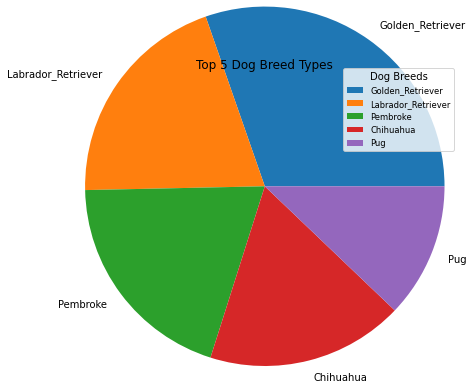

```python
#Visualise top 5 types of dog breeds
label=totals[0:5].index
plt.pie( totals[0:5],labels=label, radius=2.0, frame=False)
plt.legend(label, borderaxespad=0, title='Dog Breeds', fontsize='small', bbox_to_anchor=(0.85,1.025), loc="best")
plt.title('Top 5 Dog Breed Types', loc='center')
plt.subplots_adjust(left=0.1, bottom=0.1)
plt.show()
```

```python
plt.savefig('pie.png');
```

#### Comment: It is clearly depicted from the pie chart that Golden Retriever dog type is the most common breed from the data

### 3. Is there a correlation between a post's rating and the number of retweets?

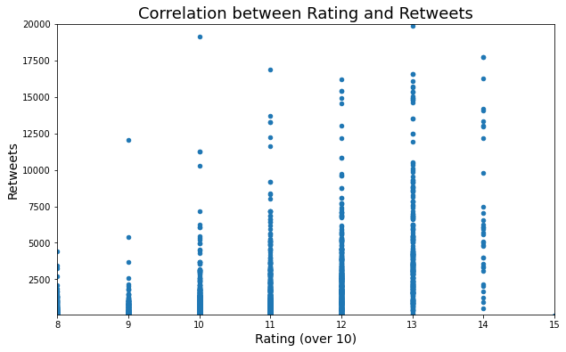

```python
combo_df.plot(x = "rating_numerator", y = "retweet_count", kind ='scatter', figsize=(10,6))
plt.title('Correlation between Rating and Retweets', fontsize=18)
plt.xlim([8,15])
plt.ylim([100,20000])
plt.xlabel('Rating (over 10)', fontsize=14)
plt.ylabel('Retweets', fontsize=14)
```

```python
from scipy.stats import pearsonr
pearsonr(combo_df.rating_numerator , combo_df.retweet_count)
```

```
(0.017699511853903914, 0.4224799973323276)
```

#### Comments:

1. The above scatter diagram shows there's no correlation between the rating on a dog post and the number of retweets it received.
2. The low pearson correlation coefficient of 0.017 supports the point that there is no linear relationship between the ratings variable and the retweets variable.

### 4. Which dog cycle stage collectively amassed the highest average number of likes on their posts?

```python
combo_df.groupby('cycles')['fav_count'].mean().sort_values(ascending=False)
```

```
cycles
puppo         18605.000000
doggo         16676.230769
multicycle    12625.153846
floofer       11149.714286
None           7019.345026
pupper         5987.449761
Name: fav_count, dtype: float64
```

#### Comment:

The puppo dog stage amassed the highest average number of likes on the posts with over 18k likes while the pupper dog stage received the fewest average number of likes collectively with 5.9k

### Resources used:

```
1. github 2. stackoverflow 3. w3schools.com
```